# PSM Sešit ULTIMATE

## Dvouvýběrový t-test

- K porovnání dvou nezávislých vzorků, aby se zjistilo, zda mají tyto vzorky odlišné průměrné hodnoty.
- Nejčastěji když zjištuji statisticky významný rozdíl dvou skupin
- Nulová hypotéza = průměry obou skupin jsou stejné
- Potřebuje **normální rozdělení**
- Dva typy
  - Pokud jsou shodné rozptyly
  - Pokud nejsou shodné rozptyly

```r
## Lisi se u porodni hmotnost mezi pohlavimi (por.hmnotnost, pohlavi)?
cislo<-Kojeni2$por.hmotnost
kategorie<-Kojeni2$Hoch

# Testuju normalitu
# Normalita se testuje pro kazdou skupinu zvlast
# QQ-ploty
par(mfrow=c(1,2))
tapply(cislo,kategorie,PlotQQ)
```

```
             dívka               hoch
"popa4/2024-03-23" "popa4/2024-03-23"
```

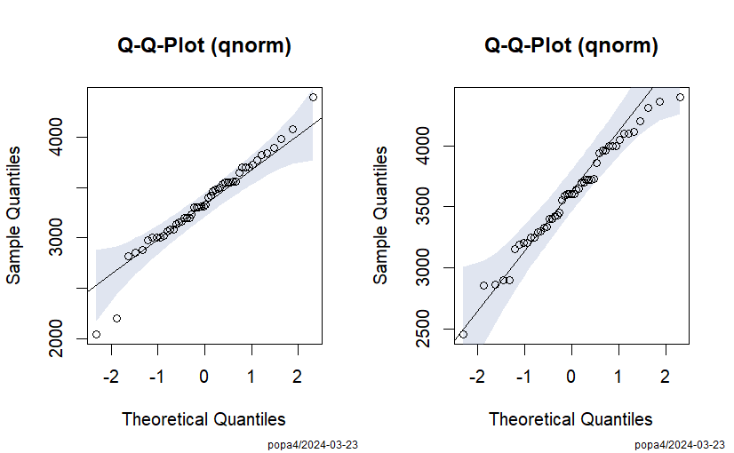

```r
par(mfrow=c(1,1))
```

```r
# Shapiro-wilk
tapply(cislo,kategorie,shapiro.test)
```

```
$dívka

    Shapiro-Wilk normality test

data:  X[[i]]
W = 0.96043, p-value = 0.09265


$hoch

    Shapiro-Wilk normality test

data:  X[[i]]
W = 0.98177, p-value = 0.6414
```

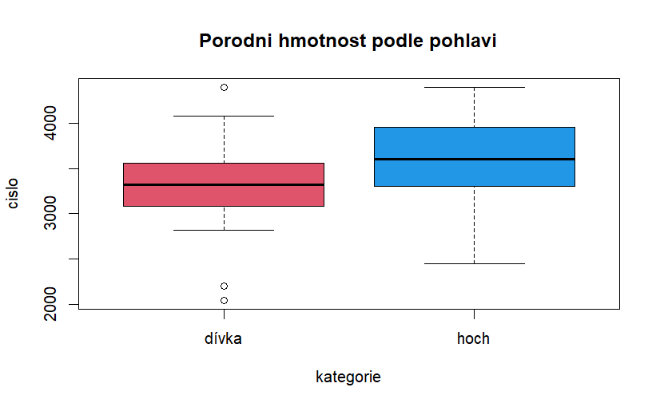

```r
# Boxplot ať zjistíme okometricky víc informací
boxplot(cislo~kategorie,main="Porodni hmotnost podle pohlavi",col=c(2,4))
```

```r
# Testuju shodnost rozptylů
var.test(cislo~kategorie) # test shodnosti rozptylů
```

```
    F test to compare two variances

data:  cislo by kategorie
F = 0.95975, num df = 49, denom df = 48, p-value = 0.886
alternative hypothesis: true ratio of variances is not equal to 1
95 percent confidence interval:
 0.5425358 1.6949240
sample estimates:
ratio of variances
         0.9597457
```

```r
# H0: rozptyly se nelisi; H1: rozptyly se lisi
# p-hodnota = 0.886 > alfa (0.05) -> nezamitame H0 (Rozptyly jsou shodne)

# Dvouvýběrový t-test
t.test(cislo~kategorie,var.eq=T) # Shodné rozptyly
```

```
    Two Sample t-test

data:  cislo by kategorie
t = -2.8391, df = 97, p-value = 0.005512
alternative hypothesis: true difference in means between group dívka and group hoch is not equal to 0
95 percent confidence interval:
 -413.22861  -73.18772
sample estimates:
mean in group dívka  mean in group hoch
           3349.200            3592.408
```

```r
#t.test(cislo~kategorie,var.eq=F) # Neshodné rozptyly
```

## Dvouvýběrový Wilcoxonův test

- K porovnání dvou nezávislých vzorků, aby se zjistilo, zda mají tyto vzorky odlišné průměrné hodnoty.
- Nejčastěji když zjištuji statisticky významný rozdíl dvou skupin
- Nulová hypotéza = průměry obou skupin jsou stejné
- Pro **nenormální rozdělení**
- Dva typy
  - Pokud jsou shodné rozptyly
  - Pokud nejsou shodné rozptyly
  - U použítí funkce v R na tom nezáleží, funcke si to sama rozezná

```r
## Lisi se vek maminek v Praze a na venkove (vekM, Porodnice)?
cislo<-Kojeni2$vekM
kategorie<-Kojeni2$Porodnice

# Testuju normalitu
# Normalita se testuje pro kazdou skupinu zvlast
# QQ-ploty
par(mfrow=c(1,2))
tapply(cislo,kategorie,PlotQQ)
```

```
             Praha             venkov
"popa4/2024-03-23" "popa4/2024-03-23"
```

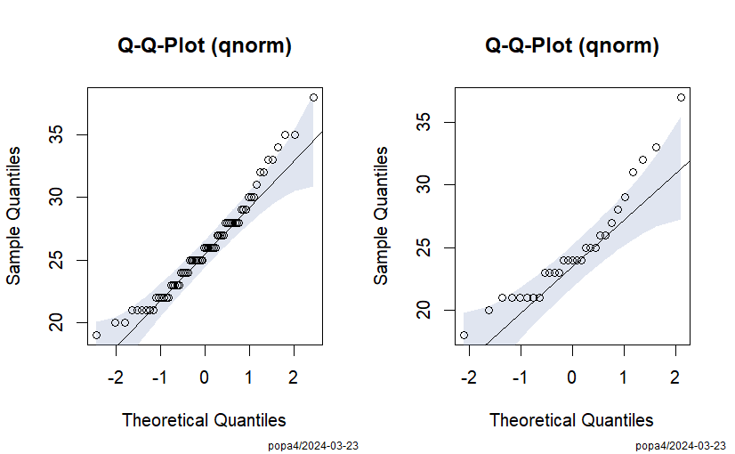

```r
par(mfrow=c(1,1))
```

```r
# Shapiro-wilk
tapply(cislo,kategorie,shapiro.test)
```

```
$Praha

    Shapiro-Wilk normality test

data:  X[[i]]
W = 0.95963, p-value = 0.02389


$venkov

    Shapiro-Wilk normality test

data:  X[[i]]
W = 0.91161, p-value = 0.01879
```

```r
var.test(cislo~kategorie)
```

```
    F test to compare two variances

data:  cislo by kategorie
F = 0.88223, num df = 69, denom df = 28, p-value = 0.6589
alternative hypothesis: true ratio of variances is not equal to 1
95 percent confidence interval:
 0.4498368 1.5897818
sample estimates:
ratio of variances
          0.882231
```

```r
  # p-hodnota = 0.6589 > alfa (0.05) -> nezamitame H0
  # predpoklad shody rozptylu je splnen

wilcox.test(cislo~kategorie)
```

```
    Wilcoxon rank sum test with continuity correction

data:  cislo by kategorie
W = 1234.5, p-value = 0.09097
alternative hypothesis: true location shift is not equal to 0
```

```r
  # p-hodnota = 0.09097 > alfa (0.05) -> nezamitame H0
  #   neprokazalo se, ze by se vek matek v Praze a na venkove vyznamne lisil.
```

# Hodina 2

```r
force(mtcars)
```

|  | mpg | cyl | disp | hp | drat | wt | qsec | vs | am | gear | carb |
| --- | --- | --- | --- | --- | --- | --- | --- | --- | --- | --- | --- |
| Mazda RX4 | 21.0 | 6 | 160.0 | 110 | 3.90 | 2.620 | 16.46 | 0 | 1 | 4 | 4 |
| Mazda RX4 Wag | 21.0 | 6 | 160.0 | 110 | 3.90 | 2.875 | 17.02 | 0 | 1 | 4 | 4 |
| Datsun 710 | 22.8 | 4 | 108.0 | 93 | 3.85 | 2.320 | 18.61 | 1 | 1 | 4 | 1 |
| Hornet 4 Drive | 21.4 | 6 | 258.0 | 110 | 3.08 | 3.215 | 19.44 | 1 | 0 | 3 | 1 |
| Hornet Sportabout | 18.7 | 8 | 360.0 | 175 | 3.15 | 3.440 | 17.02 | 0 | 0 | 3 | 2 |
| Valiant | 18.1 | 6 | 225.0 | 105 | 2.76 | 3.460 | 20.22 | 1 | 0 | 3 | 1 |
| Duster 360 | 14.3 | 8 | 360.0 | 245 | 3.21 | 3.570 | 15.84 | 0 | 0 | 3 | 4 |
| Merc 240D | 24.4 | 4 | 146.7 | 62 | 3.69 | 3.190 | 20.00 | 1 | 0 | 4 | 2 |
| Merc 230 | 22.8 | 4 | 140.8 | 95 | 3.92 | 3.150 | 22.90 | 1 | 0 | 4 | 2 |
| Merc 280 | 19.2 | 6 | 167.6 | 123 | 3.92 | 3.440 | 18.30 | 1 | 0 | 4 | 4 |

[output cut: 22 more lines]

```r
library(DescTools)
```

## ANOVA

- Podobně jako dvouvýběrový t-test porovnává střední hodnoty více vzorků
- Pro 3 a víc vzorků
- Potřebuje normální rozdělení reziduí (residua jsou rozdíly mezi pozorovanými hodnotami a predikovanými hodnotami modelu) nebo normální rozdělení dat v rámci každé skupiny. (Budeme pracovat s rezidui)
- Podle shodnosti rozptylu různé typy testu

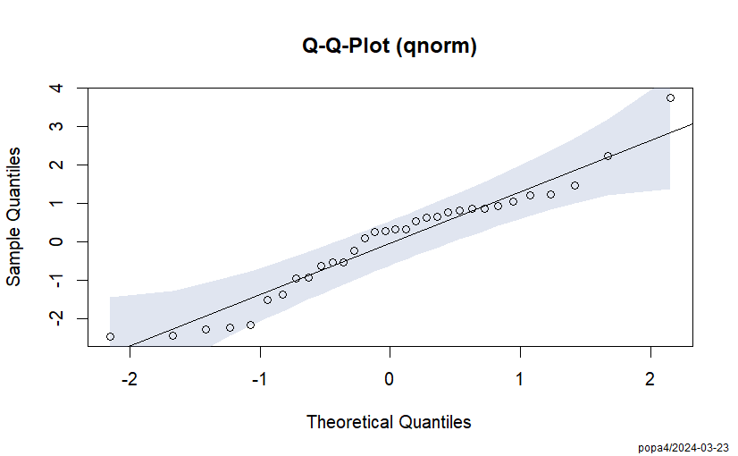

```r
# Lisi se cas, za nejz ujedou auta 1/4 mile podle poctu valcu?
cislo<-mtcars$qsec
kategorie<-as.factor(mtcars$cyl)

# Normalita se testuje pro residua linearniho modelu
#   H0: data maji normalni rozdeleni vs. H1: data nemaji normalni rozdeleni
res<-residuals(lm(cislo~kategorie))
PlotQQ(res)
```

```r
  # body lezi priblizne na primce - data maji priblizne normalni rozdeleni
# Kdo chce, muze i ciselny test, ale neni nutne
shapiro.test(res)
```

```
    Shapiro-Wilk normality test

data:  res
W = 0.9499, p-value = 0.1432
```

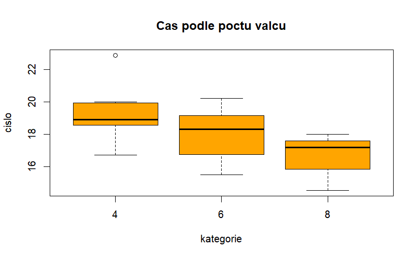

```r
  # p-hodnota 0.1432 > alfa -> nezamitame H0,
  #   data maji priblizne normalni rozdeleni -> pouziji parametrickou ANOVU

# nejprve graficke zobrazeni
boxplot(cislo~kategorie,main="Cas podle poctu valcu",col="orange")
```

```r
  # cas s poctem valcu klesa
```

```r
# testujeme hypotezy
  # H0: vsechny skupiny jsou stejne;  H1: alespon jedna skupina se lisi
  # H0: cas na poctu valcu nezavisi; H1: cas na poctu valcu zavisi

# Test shody rozptylu
# U ANOVY se používá bartlett test
  # dle vysledku se voli typ ANOVy
# Test shody rozptylu
  # H0: rozptyly se nelisi; H1: rozptyly se lisi
bartlett.test(cislo~kategorie)
```

```
    Bartlett test of homogeneity of variances

data:  cislo by kategorie
Bartlett's K-squared = 1.573, df = 2, p-value = 0.4554
```

```r
  # p-hodnota = 0.4554 > alfa (0.05) -> nezamitame H0
  #   rozptyly jsou priblizne shodne, pouzijeme klasickou ANOVu
# Analyza rozptylu pro pripad, ze se lisi variabilita ve skupinach
oneway.test(cislo~kategorie, var.equal = FALSE)
```

```
    One-way analysis of means (not assuming equal variances)

data:  cislo and kategorie
F = 7.7044, num df = 2.000, denom df = 14.047, p-value = 0.005512
```

```r
anova(aov(cislo~kategorie))
```

```
Analysis of Variance Table

Response: cislo
          Df Sum Sq Mean Sq F value   Pr(>F)
kategorie  2 34.606 17.3029  7.7938 0.001955 **
Residuals 29 64.382  2.2201
---
Signif. codes:  0 ‘***’ 0.001 ‘**’ 0.01 ‘*’ 0.05 ‘.’ 0.1 ‘ ’ 1
```

```r
  # tabulka analyzy rozptylu
  # p-hodnota = 0.001955 < alfa (0.05) -> zamitame H0, plati H1
  #   cas se podle poctu valcu lisi
```

```r
# POKUD by  nebylo normální rozdělení, nebo neshodné rozptyly tak by se použila neparametrická verze anovy
kruskal.test(cislo ~ kategorie)
```

```
    Kruskal-Wallis rank sum test

data:  cislo by kategorie
Kruskal-Wallis chi-squared = 10.155, df = 2, p-value = 0.006235
```

```r
# Muze prijit doplnujici otazka: ktere dvojice skupin se od sebe vyznamne lisi?
# parove srovnani
TukeyHSD(aov(cislo~kategorie))
```

```
  Tukey multiple comparisons of means
    95% family-wise confidence level

Fit: aov(formula = cislo ~ kategorie)

$kategorie
        diff       lwr        upr     p adj
6-4 -1.16013 -2.939271  0.6190113 0.2574564
8-4 -2.36513 -3.847748 -0.8825122 0.0013300
8-6 -1.20500 -2.908398  0.4983980 0.2053353
```

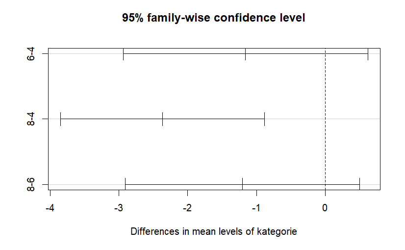

```r
  # jen 8 valcu a 4 valce
plot(TukeyHSD(aov(cislo~kategorie)))
```